# Predicting exercise quality using Machine Learning

Coursera Student

18 November 2015

# Executive summary

The goal of this paper is to explain how machine learning could be used to accurately predict the manner in which subjects performed an exercise. This would improve the quality of physical activity and result in added health benefits.

Given the primary objective is thus accuracy a Random Forest (RF) model was built, which is also robust to variance and bias.

RF modelling has no need for cross-validation for unbiased estimates due to it being estimated internally during the run. That said, Coursera’s explicit requirements include cross validation so a random test set will be generated and the model evaluated for accuracy by estimating an out of sample error rate.

The result was > 99% accuracy in both the test (as randomly generated) and prediction (as submitted to Coursera) sets.

Note the paper was not written to be reproducible given an .RMD file is included in this github repository showing all relevant code.

# Background

Using devices such as Jawbone Up, Nike FuelBand, and Fitbit it is now possible to collect a large amount of data about personal activity relatively inexpensively. These type of devices are part of the quantified self movement a group of enthusiasts who take measurements about themselves regularly to improve their health, to find patterns in their behaviour, or because they are tech geeks.

One thing that people regularly do is quantify how much of a particular activity they do, but they rarely quantify how well they do it. Thus we’ll use data from accelerometers on the belt, forearm, arm, and dumbbell of 6 participants. They were asked to perform barbell lifts correctly and incorrectly in 5 different ways.

More information is available from the website here: http://groupware.les.inf.puc-rio.br/har (see the section on the Weight Lifting Exercise Dataset).

# Data sourcing

Training and Prediction (not test) data was downloaded from the following URL: https://d396qusza40orc.cloudfront.net/predmachlearn/ . The dimensions are shown below.

```r
dim(raw)
```

```
## [1] 19622   160
```

```r
dim(prediction)
```

```
## [1]  20 160
```

# Data exploration

The below plot shows exercise classe (to be predicted), subject and a random measure over a standardised time variable. Also included is the new_window variable to see if window variables are of importance (seems not, but may be reconsidered if accuracy is low).

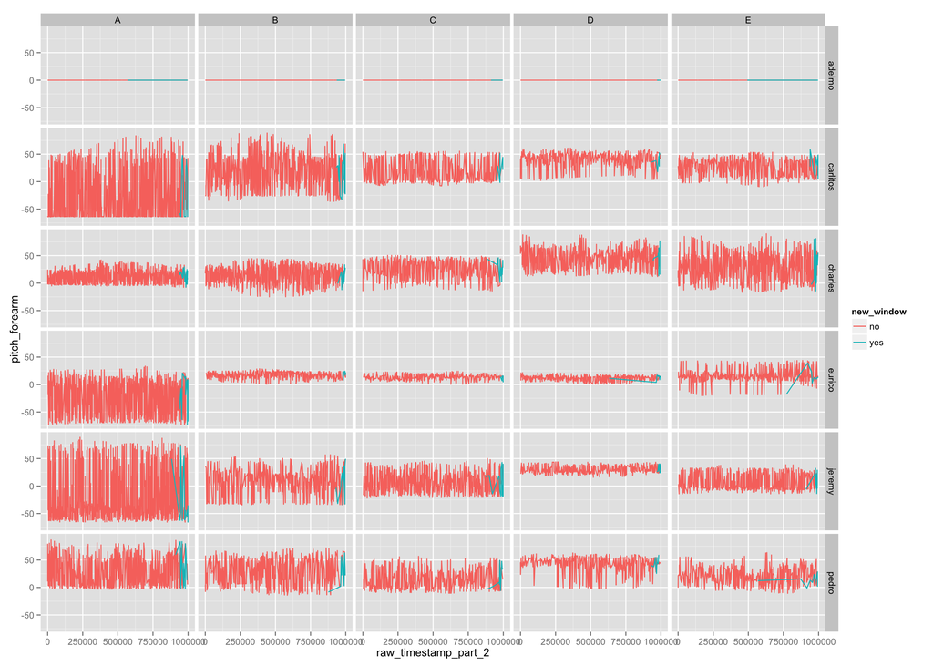

```r
ggplot(data = raw, aes(x=raw_timestamp_part_2,y=pitch_forearm,col = new_window)) + geom_line() + facet_grid(user_name ~ classe)
```

# Data cleaning

To allow optimal running time with limited resource (old computer) and reduced variance we remove redundant variables from both source and prediction data sets:

- missing values for more than 95% of observations
- low information value i.e. nearZeroVar is True
- line identification variables
- date stamps and window indicators as raw timestamps will be used instead

```r
# Missing values
prepared <- raw[, colSums(is.na(raw)) < nrow(raw)*.95]
prediction <- prediction[, colSums(is.na(raw)) < nrow(raw)*.95]
# Low information value
nzv <- nearZeroVar(prepared, saveMetrics = F)
prepared <- prepared[,-nzv]
prediction <- prediction[,-nzv]
# IDs, dates and window variables
prepared <- prepared[,-c(1,5:7)]
prediction <- prediction[,-c(1,5:7)]
# Review new dimensions
dim(prepared)
```

```
## [1] 19622    55
```

```r
dim(prediction)
```

```
## [1] 20 55
```

# Testing for highly correlated variables

Per the below ordered plot there are only a few highly correlated variables and thus combining and elimination through for example Principle Component Analysis (PCA) is not considered necessary.

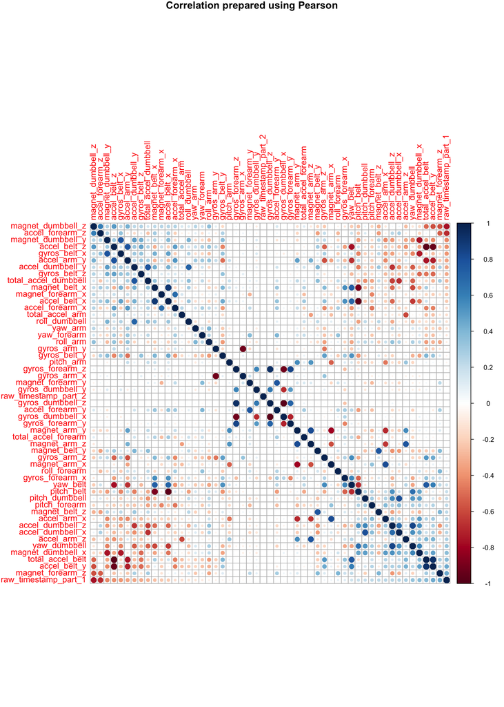

# Skew and kurtosis

Below shows kurtosis for each numeric variable of the dataset. Larger values mean sharper peaks and flatter tails. Positive values indicate an acute peak around the mean. Negative values indicate a smaller peak around the mean.

```
## raw_timestamp_part_1 raw_timestamp_part_2           pitch_belt
##        -1.012394e+00        -1.186941e+00        -9.148150e-02
##             yaw_belt     total_accel_belt         gyros_belt_x
##        -5.825986e-01        -1.753249e+00         6.555312e+00
##         gyros_belt_y         gyros_belt_z         accel_belt_x
##         4.718405e+00         6.287342e+00        -9.353187e-02
##         accel_belt_y         accel_belt_z        magnet_belt_x
##        -1.569365e+00        -1.834606e+00         2.099836e+00
##        magnet_belt_y        magnet_belt_z             roll_arm
##         7.973007e+00         1.234808e+01        -4.099837e-01
##            pitch_arm              yaw_arm      total_accel_arm
##         2.848569e-01        -1.314055e-01        -2.878825e-01
##          gyros_arm_x          gyros_arm_y          gyros_arm_z
##        -4.312016e-01         6.461085e-01         4.123372e-02
##          accel_arm_x          accel_arm_y          accel_arm_z
##        -7.842971e-01        -1.039067e+00         8.815773e-01
##         magnet_arm_x         magnet_arm_y         magnet_arm_z
##        -1.600661e+00        -8.287751e-01         1.000597e-01
##        roll_dumbbell       pitch_dumbbell         yaw_dumbbell
##        -4.405801e-01        -1.333361e-01        -1.429286e+00
## total_accel_dumbbell     gyros_dumbbell_x     gyros_dumbbell_y
##        -8.276839e-01         1.709348e+04         2.681477e+03
##     gyros_dumbbell_z     accel_dumbbell_x     accel_dumbbell_y
##         1.885261e+04         1.067656e+00        -4.297979e-01
##     accel_dumbbell_z    magnet_dumbbell_x    magnet_dumbbell_y
##        -5.432732e-01         1.443158e+00         2.781936e+00
##    magnet_dumbbell_z         roll_forearm        pitch_forearm
##         2.745407e-01        -7.578136e-01         8.781658e-01
##          yaw_forearm  total_accel_forearm      gyros_forearm_x
##        -1.142683e+00         1.042816e+00         6.988494e+01
##      gyros_forearm_y      gyros_forearm_z      accel_forearm_x
##         5.150217e+03         1.527176e+04        -6.899268e-01
##      accel_forearm_y      accel_forearm_z     magnet_forearm_x
##        -1.174921e-01        -9.104490e-01        -7.741406e-02
##     magnet_forearm_y     magnet_forearm_z
##        -4.552205e-01         8.995480e-01
```

```
## raw_timestamp_part_1 raw_timestamp_part_2           pitch_belt
##        -1.615294e-01         2.336908e-03        -1.001514e+00
##             yaw_belt     total_accel_belt         gyros_belt_x
##         9.071928e-01         3.488594e-02        -5.829461e-01
##         gyros_belt_y         gyros_belt_z         accel_belt_x
##        -5.517356e-02         2.072319e-01         9.716888e-01
##         accel_belt_y         accel_belt_z        magnet_belt_x
##         1.561561e-01         2.028705e-02         1.433152e+00
##        magnet_belt_y        magnet_belt_z             roll_arm
##        -2.235841e+00         1.726717e-01        -1.760536e-01
##            pitch_arm              yaw_arm      total_accel_arm
##         2.033859e-01        -9.192407e-02         6.498848e-02
##          gyros_arm_x          gyros_arm_y          gyros_arm_z
##        -2.876911e-01         1.352115e-01        -1.706878e-01
##          accel_arm_x          accel_arm_y          accel_arm_z
##         3.424075e-01         9.821943e-02        -8.493684e-01
##         magnet_arm_x         magnet_arm_y         magnet_arm_z
##        -1.549503e-01        -4.673951e-01        -1.140362e+00
##        roll_dumbbell       pitch_dumbbell         yaw_dumbbell
##        -7.395314e-01         5.223497e-01         2.168622e-01
## total_accel_dumbbell     gyros_dumbbell_x     gyros_dumbbell_y
##         5.975222e-01        -1.263212e+02         3.164827e+01
##     gyros_dumbbell_z     accel_dumbbell_x     accel_dumbbell_y
##         1.359534e+02        -4.595247e-01         3.540569e-01
##     accel_dumbbell_z    magnet_dumbbell_x    magnet_dumbbell_y
##        -1.005007e-01         1.694024e+00        -1.809787e+00
##    magnet_dumbbell_z         roll_forearm        pitch_forearm
##         8.776033e-01        -4.644033e-01        -5.102962e-01
##          yaw_forearm  total_accel_forearm      gyros_forearm_x
##        -2.667299e-01        -5.783246e-01        -1.923786e+00
##      gyros_forearm_y      gyros_forearm_z      accel_forearm_x
##         5.132379e+01         1.160762e+02        -2.293637e-01
##      accel_forearm_y      accel_forearm_z     magnet_forearm_x
##        -6.506143e-01         4.364184e-01         6.432952e-01
##     magnet_forearm_y     magnet_forearm_z
##        -7.444700e-01        -1.221061e+00
```

# Building a Random Forrest model

## Holding out an evaluation set

Per project requirements a test set is being randomly selected to evaluate the model against. Given the large amount of observations a 60% training : 40% test split is considered appropriate. The dimensions of the two data sets are shown below.

```r
dim(training)
```

```
## [1] 11776    55
```

```r
dim(test)
```

```
## [1] 7846   55
```

## Setting tuning parameters

Given the data is time series based a ‘Timeslice’ control parameter is created to be passed to the modelling function for cross validation purposes during the running of the model.

```r
fitControl2 <- trainControl(method='timeslice', initialWindow=120, fixedWindow=TRUE, horizon=120)
```

## Train a random forrest model

Per the below our estimated out of sample error rate (OOB) is 0.36%, which is considered sufficient for our stated purpose.

```
##
## Call:
##  randomForest(formula = classe ~ ., data = training, ntree = 100,      mtry = 7, importance = TRUE, replace = FALSE, allowparallel = T,      trControl = fitControl2, na.action = randomForest::na.roughfix)
##                Type of random forest: classification
##                      Number of trees: 100
## No. of variables tried at each split: 7
##
##         OOB estimate of  error rate: 0.36%
## Confusion matrix:
##      A    B    C    D    E  class.error
## A 3346    2    0    0    0 0.0005973716
## B    8 2266    5    0    0 0.0057042563
## C    0    8 2045    1    0 0.0043816943
## D    0    0   16 1912    2 0.0093264249
## E    0    0    0    0 2165 0.0000000000
```

## Estimating the error using cross-validation

The test set is passed to the newly created RF model and results are analysed in a confusion matrix. Accuracy is given as 99.78%, thus the expect out of sample error is 0.22%.

The plot shows that a sufficient number of trees have been constructed (100) and additional trees would not significantly reduce the observed error rate.

```
## Confusion Matrix and Statistics
##
##           Reference
## Prediction    A    B    C    D    E
##          A 2232    0    0    0    0
##          B    4 1514    0    0    0
##          C    0    3 1365    0    0
##          D    0    0    5 1281    0
##          E    0    0    0    5 1437
##
## Overall Statistics
##
##                Accuracy : 0.9978
##                  95% CI : (0.9965, 0.9987)
##     No Information Rate : 0.285
##     P-Value [Acc > NIR] : < 2.2e-16
##
##                   Kappa : 0.9973
##  Mcnemar's Test P-Value : NA
##
## Statistics by Class:
##
##                      Class: A Class: B Class: C Class: D Class: E
## Sensitivity            0.9982   0.9980   0.9964   0.9961   1.0000
## Specificity            1.0000   0.9994   0.9995   0.9992   0.9992
## Pos Pred Value         1.0000   0.9974   0.9978   0.9961   0.9965
## Neg Pred Value         0.9993   0.9995   0.9992   0.9992   1.0000
## Prevalence             0.2850   0.1933   0.1746   0.1639   0.1832
## Detection Rate         0.2845   0.1930   0.1740   0.1633   0.1832
## Detection Prevalence   0.2845   0.1935   0.1744   0.1639   0.1838
## Balanced Accuracy      0.9991   0.9987   0.9979   0.9977   0.9996
```

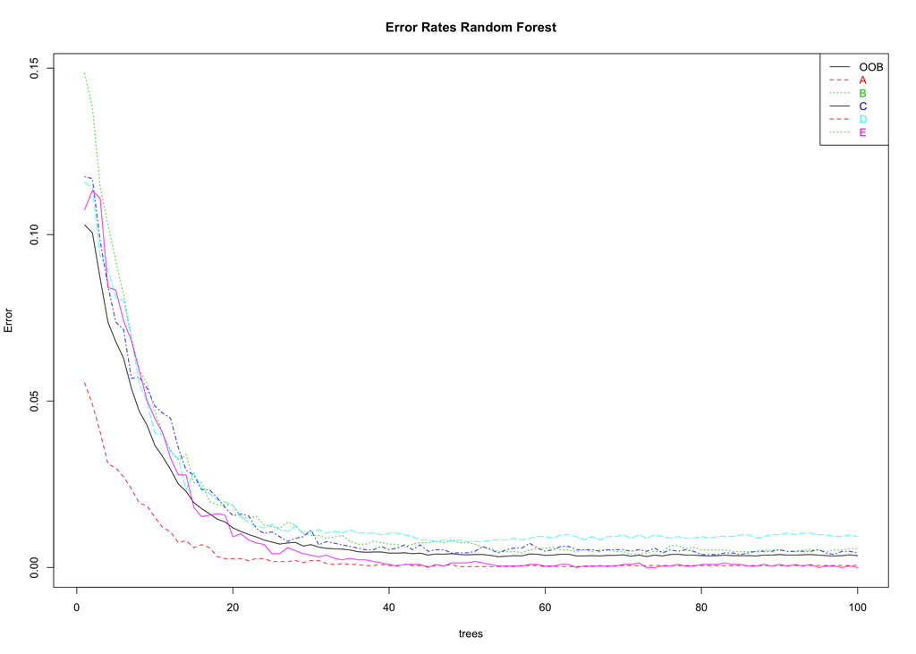

## Predicitng exercise classes for submission to Coursera

The model is applied to the prediction data set as loaded earlier. The below results gave 100% accuracy per Coursera’s online evaluation.

```r
predict(modelFit,prediction[,-55])
```

```
##  1  2  3  4  5  6  7  8  9 10 11 12 13 14 15 16 17 18 19 20
##  B  A  B  A  A  E  D  B  A  A  B  C  B  A  E  E  A  B  B  B
## Levels: A B C D E
```